# League of Legends SoloQ matches at 15 minutes 2024

Author

Paweł Niedziela

## Cel badania

Celem badania jest budowa optymalnego modelu klasyfikacyjnego za pomocą wybranych algorytmów uczenia maszynowego. Jego zadaniem będzie zweryfikowanie na podstawie podanych predyktorów która drużyna wygrała mecz.

## Opisz zbioru badawczego

Zbiór danych **League of Legends SoloQ matches at 15 minutes 2024** został pobrany ze strony [Kaggle](https://www.kaggle.com/datasets/karlorusovan/league-of-legends-soloq-matches-at-10-minutes-2024/data).

### Informacje o zbiorze danych[^1]

Ten zbiór danych zawiera dane dotyczące pierwszych 15 minut rozgrywki dla ponad 24 tysięcy meczów solo w kolejce z europejskich serwerów (EUNE i EUW). Średnie ELO meczów wynosi od średniego szmaragdu do wysokiego diamentu. Głównym celem zbioru danych jest pomoc w trenowaniu modeli do przewidywania zwycięzcy na podstawie przebiegu pierwszych 15 minut meczu.

Istnieje 14 cech dla czerwonej i 14 cech dla niebieskiej drużyny (cecha blueTeamFirstBlood liczy się dla obu drużyn, ponieważ mówi nam, która drużyna otrzymała pierwsze zabójstwo), a docelową cechą jest blueWin. blueWin == 1 oznacza zwycięstwo niebieskiej drużyny, a blueWin == 0 oznacza, że wygrała drużyna czerwona.

Notatnik szczegółowo opisujący proces zbierania danych jest dostępny w zakładce kod. Mamy nadzieję, że pomoże to komuś ulepszyć metodę zbierania danych lub ponownie wykorzystać kod w innym projekcie.

Nie powinno być żadnych brakujących wartości.

### Objaśnienia zmiennych

- `matchId` - identyfikator meczu ligowego
- `blueTeamControlWardsPlaced` - totemy kontrolne/różowe umieszczone przez niebieską drużynę (mogą mieć wartości odstające w oparciu o możliwość, że drużyna podda się i kupi wiele totemów na koniec i umieści je)
- `blueTeamWardsPlaced` - wszystkie rodzaje totemów (kontrolne, strażniczy, ghost poro itp.) umieszczone przez niebieską drużynę
- `blueTeamTotalKills` - całkowita liczba zabójstw dokonanych przez niebieską drużynę, zabicie wrogiego bohatera generuje złoto i doświadczenie.
- `blueTeamDragonKills` - całkowita liczba smoków zabitych przez niebieską drużynę, smoki to elitarne potwory, które po zabiciu dają określone stałe wzmocnienia, a zabicie czwartego smoka daje drużynie smoczą duszę
- `blueTeamHeraldKills` - całkowita liczba zabitych heraldów przez niebieską drużynę, herald jest elitarnym potworem, który pomaga w niszczeniu budynków wroga (wieżyczek, inhibitorów i nexusa) oraz przepychaniu linii.
- `blueTeamTowersDestroyed` - łączna liczba wież zniszczonych przez niebieską drużynę, wieże to struktury obronne na alei, które atakują stwory i bohaterów.
- `blueTeamInhibitorsDestroyed` - całkowita liczba inhibitorów zniszczonych przez niebieską drużynę, inhibitor to budynek chroniony przez wieże, a gdy zostanie zniszczony, pozwala super stworom na odrodzenie się po stronie drużyny, która go zniszczyła.
- `blueTeamTurretPlatesDestroyed` - całkowita liczba płyt wieżyczek zniszczonych przez niebieską drużynę, płyty wieżyczek to tarcze ochronne na wieżach, które generują złoto, gdy zostaną zniszczone i całkowicie odpadają po 14 minutach.
- `blueTeamFirstBlood` - 1 pierwsza krew drużyny niebieskiej, 0 pierwsza krew drużyny czerwonej; pierwsza krew generuje dodatkowe złoto za zabójstwo.
- `blueTeamMinionsKilled` - całkowita liczba stworów zabitych przez niebieską drużynę; stwory generują złoto i doświadczenie oraz są jednym z głównych źródeł dochodu w grze.
- `blueTeamJungleMinions` - całkowita liczba stworów w dżungli zabitych przez niebieską drużynę, również generują złoto, ale doświadczenie zdobywa tylko dżungler.
- `blueTeamTotalGold` - całkowite złoto zdobyte przez niebieską drużynę z różnych źródeł (budynki, zabójstwa, asysty, miniony,…)
- `blueTeamXp` - całkowite doświadczenie niebieskiej drużyny, skorelowane z całkowitą ilością spędzoną w alejach (minion nie musi zostać zabity przez bohatera, aby zdobyć doświadczenie) i całkowitą ilością zabitych bohaterów.
- `blueTeamTotalDamageToChamps` - całkowite obrażenia zadane przez niebieską drużynę wrogim bohaterom
- `blueWin` - 1 zwycięstwo niebieskiej drużyny, 0 zwycięstwo czerwonej drużyny
- `redTeamControlWardsPlaced` - totemy kontrolne/różowe umieszczone przez czerwoną drużynę (mogą mieć wartości odstające w oparciu o możliwość, że drużyna podda się i kupi wiele totemów na koniec i umieści je)
- `redTeamWardsPlaced` - wszystkie rodzaje totemów (kontrolne, strażniczy, ghost poro itp.) umieszczone przez czerwoną drużynę
- `redTeamTotalKills` - całkowita liczba zabójstw dokonanych przez czerwoną drużynę, zabicie wrogiego bohatera generuje złoto i doświadczenie.
- `redTeamDragonKills` - całkowita liczba smoków zabitych przez czerwoną drużynę, smoki to elitarne potwory, które po zabiciu dają określone stałe wzmocnienia, a zabicie czwartego smoka daje drużynie smoczą duszę
- `redTeamHeraldKills` - całkowita liczba zabitych heraldów przez czerwoną drużynę, herald jest elitarnym potworem, który pomaga w niszczeniu budynków wroga (wieżyczek, inhibitorów i nexusa) oraz przepychaniu linii.
- `redTeamTowersDestroyed` - łączna liczba wież zniszczonych przez czerwoną drużynę, wieże to struktury obronne na alei, które atakują stwory i bohaterów.
- `redTeamInhibitorsDestroyed` - całkowita liczba inhibitorów zniszczonych przez czerwoną drużynę, inhibitor to budynek chroniony przez wieże, a gdy zostanie zniszczony, pozwala super stworom na odrodzenie się po stronie drużyny, która go zniszczyła.
- `redTeamTurretPlatesDestroyed` - całkowita liczba płyt wieżyczek zniszczonych przez czerwoną drużynę, płyty wieżyczek to tarcze ochronne na wieżach, które generują złoto, gdy zostaną zniszczone i całkowicie odpadają po 14 minutach.
- `redTeamMinionsKilled` - całkowita liczba stworów zabitych przez czerwoną drużynę; stwory generują złoto i doświadczenie oraz są jednym z głównych źródeł dochodu w grze.
- `redTeamJungleMinions` - całkowita liczba stworów w dżungli zabitych przez czerwoną drużynę, również generują złoto, ale doświadczenie zdobywa tylko dżungler.
- `redTeamTotalGold` - całkowite złoto zdobyte przez czerwoną drużynę z różnych źródeł (budynki, zabójstwa, asysty, miniony,…)
- `redTeamXp` - całkowite doświadczenie czerwonej drużyny, skorelowane z całkowitą ilością spędzoną w alejach (minion nie musi zostać zabity przez bohatera, aby zdobyć doświadczenie) i całkowitą ilością zabitych bohaterów.
- `redTeamTotalDamageToChamps` - całkowite obrażenia zadane przez czerwoną drużynę wrogim bohaterom

Wszystkie zmienne są numeryczne z wyjątkiem `blueWin` oraz `blueTeamFirstBlood`.

```r
mecze_at_15 <- import("C:\\Users\\pawel\\Desktop\\Projekt_Eksploracja_Danych\\match_data_v5.csv")
knitr::kable(str(mecze_at_15))
```

```
'data.frame':   24225 obs. of  29 variables:
 $ matchId                      : chr  "EUW1_6882489515'" "EUW1_6882416210'" "EUW1_6881092720'" "EUW1_6879405717'" ...
 $ blueTeamControlWardsPlaced   : int  2 2 2 3 3 2 3 0 2 2 ...
 $ blueTeamWardsPlaced          : int  23 46 19 28 30 24 22 30 30 34 ...
 $ blueTeamTotalKills           : int  4 12 13 8 11 3 15 11 7 15 ...
 $ blueTeamDragonKills          : int  2 1 0 0 1 0 2 1 0 0 ...
 $ blueTeamHeraldKills          : int  0 0 0 1 1 0 0 0 0 1 ...
 $ blueTeamTowersDestroyed      : int  0 1 0 1 1 0 1 0 1 0 ...
 $ blueTeamInhibitorsDestroyed  : int  0 0 0 0 0 0 0 0 0 0 ...
 $ blueTeamTurretPlatesDestroyed: int  7 10 11 9 7 16 10 8 9 9 ...
 $ blueTeamFirstBlood           : int  0 0 0 1 0 0 0 1 1 0 ...
 $ blueTeamMinionsKilled        : int  388 348 331 355 370 369 331 392 403 314 ...
 $ blueTeamJungleMinions        : int  106 98 96 84 100 80 96 104 88 96 ...
 $ blueTeamTotalGold            : int  23923 27852 28126 27333 27772 24011 27717 27834 27339 28220 ...
 $ blueTeamXp                   : int  29798 30530 29501 30466 31066 26872 30575 31205 30398 30249 ...
 $ blueTeamTotalDamageToChamps  : int  21842 35817 38039 31338 26676 22414 31257 24044 31853 31888 ...
 $ redTeamControlWardsPlaced    : int  6 6 3 0 7 1 3 0 2 5 ...
 $ redTeamWardsPlaced           : int  34 26 241 23 26 33 128 23 23 28 ...
 $ redTeamTotalKills            : int  16 17 18 10 7 15 9 5 11 16 ...
 $ redTeamDragonKills           : int  0 0 1 1 1 2 0 0 1 1 ...
 $ redTeamHeraldKills           : int  0 0 0 0 0 1 0 0 0 0 ...
 $ redTeamTowersDestroyed       : int  2 1 2 0 1 3 1 0 0 0 ...
 $ redTeamInhibitorsDestroyed   : int  0 0 0 0 0 0 0 0 0 0 ...
 $ redTeamTurretPlatesDestroyed : int  1 4 3 5 5 3 5 2 4 2 ...
 $ redTeamMinionsKilled         : int  400 373 340 378 382 357 403 359 397 381 ...
 $ redTeamJungleMinions         : int  94 76 84 87 96 70 96 100 88 88 ...
 $ redTeamTotalGold             : int  29637 28970 30510 25157 26052 28368 28584 24105 26470 28806 ...
 $ redTeamXp                    : int  32613 30320 29464 31069 29475 30422 29831 29335 30053 31373 ...
 $ redTeamTotalDamageToChamps   : int  27239 36585 42984 28229 19245 30967 31563 24014 25791 37085 ...
 $ blueWin                      : int  1 0 0 0 1 0 1 1 1 0 ...
```

## Czyszczenie danych

### Usunięcie kolumny `matchId`

Jest to kolumna indeksująca mecze, która nie zawiera żadnych informacji.

```r
mecze_at_15 <- mecze_at_15 %>% select(-matchId)
```

### Zamienienie cech jakościowych na faktory

```r
mecze_at_15$blueTeamFirstBlood <- factor(mecze_at_15$blueTeamFirstBlood, levels = c(1,0))
mecze_at_15$blueWin <- factor(mecze_at_15$blueWin, levels = c(1,0))
```

### Sprawdzenie braku danych

```r
sum(colSums(is.na(mecze_at_15)))
```

```
[1] 0
```

W zbiorze nie ma braku danych.

### Sprawdzenie balansu klas

```r
d <- table(mecze_at_15$blueWin)
W1 <- round(d[1]/(d[1]+d[2]),3)*100
W2 <- round(d[2]/(d[1]+d[2]),3)*100
```

W tym zbiorze jest 49.5% obserwacji wskazujących na zwycięstwo drużyny niebieskiej, 50.5% obserwacji wskazujących na zwycięstwo drużyny czerwonej zatem ten zbiór jest zbalansowany.

## Selekcja cech

Przeprowadziłem selekcję cech dwoma metodami **Random Forest Feature Importance** i **Metodą Boruta**.

### Random Forest Feature Importance

Random Forest Feature Importance jest techniką służącą do oceny ważności (istotności) zmiennych w modelu lasu losowego. Polega ona na określeniu, w jakim stopniu każda zmienna przyczynia się do przewidywania zmiennej celu. Istnieją dwie główne metody oceny ważności cech w modelach lasów losowych:

##### Mean Decrease in Impurity (MDI)

MDI mierzy ważność zmiennych na podstawie zmniejszenia nieczystości indeksu Giniego przez każdą zmienną w drzewach decyzyjnych. Kiedy zmienna jest używana do podziału węzła, jej ważność jest zwiększana proporcjonalnie do zmniejszenia nieczystości. Średnie zmniejszenie nieczystości w całym lesie jest używane jako miara ważności zmiennej.

##### Mean Decrease in Accuracy (MDA)

MDA mierzy ważność zmiennych poprzez permutację wartości zmiennych w zbiorze danych i mierzenie, jak permutacja wpływa na dokładność modelu. Jeśli permutacja wartości danej zmiennej powoduje znaczne zmniejszenie dokładności modelu, zmienna ta jest uważana za ważną.

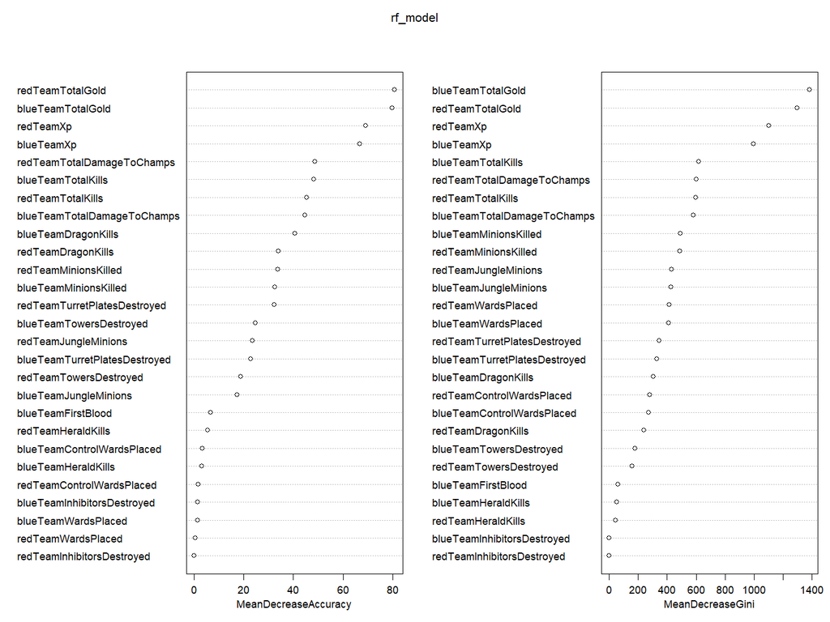

Ocena istotności zmiennych modelu RF Feature Importance

```r
importance <- importance(rf_model)
importance_s <- mean(importance[, 1:2])
important_features_rf <- rownames(importance)[importance[, 1] > mean(importance[, 1:2])]
data_reduced_rf <- mecze_at_15 %>% select(all_of(important_features_rf), blueWin)
```

Wyodrębniłamy istotność cech, jako próg (treshold) ustanowiłem średnią z wartości istotności - 19.76. Oto cechy które zostały wyselekcjonowane.

```
'data.frame':   24225 obs. of  12 variables:
 $ blueTeamTotalKills         : int  4 12 13 8 11 3 15 11 7 15 ...
 $ blueTeamDragonKills        : int  2 1 0 0 1 0 2 1 0 0 ...
 $ blueTeamMinionsKilled      : int  388 348 331 355 370 369 331 392 403 314 ...
 $ blueTeamTotalGold          : int  23923 27852 28126 27333 27772 24011 27717 27834 27339 28220 ...
 $ blueTeamXp                 : int  29798 30530 29501 30466 31066 26872 30575 31205 30398 30249 ...
 $ blueTeamTotalDamageToChamps: int  21842 35817 38039 31338 26676 22414 31257 24044 31853 31888 ...
 $ redTeamTotalKills          : int  16 17 18 10 7 15 9 5 11 16 ...
 $ redTeamDragonKills         : int  0 0 1 1 1 2 0 0 1 1 ...
 $ redTeamTotalGold           : int  29637 28970 30510 25157 26052 28368 28584 24105 26470 28806 ...
 $ redTeamXp                  : int  32613 30320 29464 31069 29475 30422 29831 29335 30053 31373 ...
 $ redTeamTotalDamageToChamps : int  27239 36585 42984 28229 19245 30967 31563 24014 25791 37085 ...
 $ blueWin                    : Factor w/ 2 levels "1","0": 1 2 2 2 1 2 1 1 1 2 ...
```

### Metoda Boruta

Metoda Boruta jest oparta na algorytmie lasu losowego, jednakże w przeciwieństwie do tradycyjnych metod selekcji cech, wykorzystuje losowe permutacje i porównania do identyfikacji istotnych cech. Dla każdej oryginalnej cech tworzona jest jej sklonowana wersja (shadow feature), która następnie jest losowa permutowana. Dalej jest przeprowadzane uczenie lasu losowego na zbiorze z danymi oryginalnymi i shadow features i liczona jest ważność cech. Istotność każdej cechy oryginalnej jest porównywana do najwyższej istotności cechy shadow, cechy które mają istotność wyższą klasyfikowane są za istotne, natomiast mniejszą za nieistotne. Klasyfikacja jest przeprowadzana iteracyjnie, aż wszystkie cechy zostaną zakwalifikowane jako istotne, nieistotne, niepewne, lub do osiągnięcia limitu iteracji.

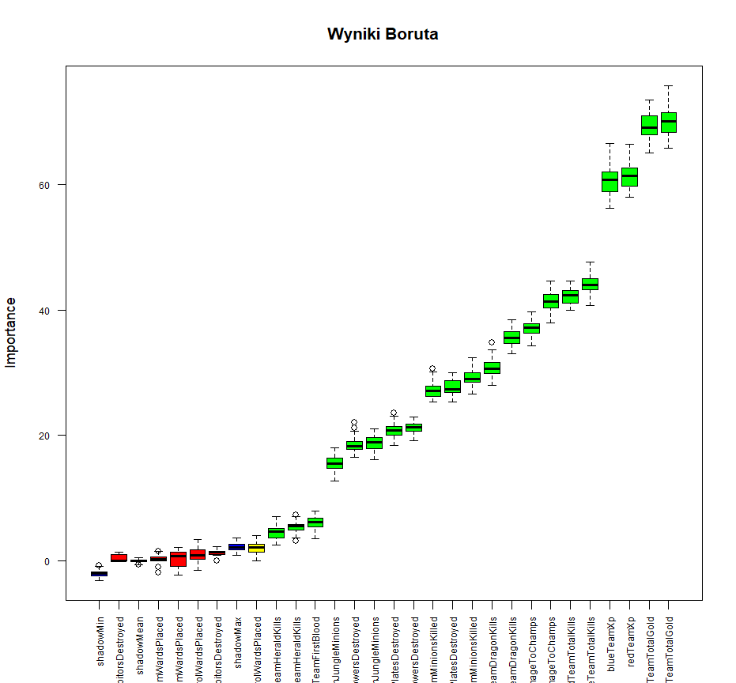

Ocena istotności zmiennych modelu Metoda Boruta

Cechy oznaczone zielonym kolorem według Metody Boruta istotne, żółtym niepewne, czerwonym nieistotne, natomiast niebieski kolor to shadow features.

```r
selected_features_boruta <- getSelectedAttributes(boruta_model, withTentative = TRUE)
data_reduced_boruta <- mecze_at_15 %>% select(all_of(selected_features_boruta), blueWin)
```

Wyodrębniamy wybrane cech i otrzymujemy zbiór z 23 zmiennymi (pamiętamy o dodaniu cechy `blueWin`).

```r
knitr::kable(str(data_reduced_boruta))
```

```
'data.frame':   24225 obs. of  23 variables:
 $ blueTeamControlWardsPlaced   : int  2 2 2 3 3 2 3 0 2 2 ...
 $ blueTeamTotalKills           : int  4 12 13 8 11 3 15 11 7 15 ...
 $ blueTeamDragonKills          : int  2 1 0 0 1 0 2 1 0 0 ...
 $ blueTeamHeraldKills          : int  0 0 0 1 1 0 0 0 0 1 ...
 $ blueTeamTowersDestroyed      : int  0 1 0 1 1 0 1 0 1 0 ...
 $ blueTeamTurretPlatesDestroyed: int  7 10 11 9 7 16 10 8 9 9 ...
 $ blueTeamFirstBlood           : Factor w/ 2 levels "1","0": 2 2 2 1 2 2 2 1 1 2 ...
 $ blueTeamMinionsKilled        : int  388 348 331 355 370 369 331 392 403 314 ...
 $ blueTeamJungleMinions        : int  106 98 96 84 100 80 96 104 88 96 ...
 $ blueTeamTotalGold            : int  23923 27852 28126 27333 27772 24011 27717 27834 27339 28220 ...
 $ blueTeamXp                   : int  29798 30530 29501 30466 31066 26872 30575 31205 30398 30249 ...
 $ blueTeamTotalDamageToChamps  : int  21842 35817 38039 31338 26676 22414 31257 24044 31853 31888 ...
 $ redTeamTotalKills            : int  16 17 18 10 7 15 9 5 11 16 ...
 $ redTeamDragonKills           : int  0 0 1 1 1 2 0 0 1 1 ...
 $ redTeamHeraldKills           : int  0 0 0 0 0 1 0 0 0 0 ...
 $ redTeamTowersDestroyed       : int  2 1 2 0 1 3 1 0 0 0 ...
 $ redTeamTurretPlatesDestroyed : int  1 4 3 5 5 3 5 2 4 2 ...
 $ redTeamMinionsKilled         : int  400 373 340 378 382 357 403 359 397 381 ...
 $ redTeamJungleMinions         : int  94 76 84 87 96 70 96 100 88 88 ...
 $ redTeamTotalGold             : int  29637 28970 30510 25157 26052 28368 28584 24105 26470 28806 ...
 $ redTeamXp                    : int  32613 30320 29464 31069 29475 30422 29831 29335 30053 31373 ...
 $ redTeamTotalDamageToChamps   : int  27239 36585 42984 28229 19245 30967 31563 24014 25791 37085 ...
 $ blueWin                      : Factor w/ 2 levels "1","0": 1 2 2 2 1 2 1 1 1 2 ...
```

## Podział danych

Dzielimy zbiory danych z przeprowadzoną selekcją cech i zbiór pełny na treningowy i testowy z proporcją 80/20.

```r
part_boruta <-  createDataPartition(y = data_reduced_boruta$blueWin, p = 0.8, list = F)
part_rf <-  createDataPartition(y = data_reduced_rf$blueWin, p = 0.8, list = F)
part_all<-  createDataPartition(y = mecze_at_15$blueWin, p = 0.8, list = F)

train_boruta <- data_reduced_boruta[part_boruta,]
test_boruta <- data_reduced_boruta[-part_boruta,]

train_rf <- data_reduced_rf[part_rf,]
test_rf <- data_reduced_rf[-part_rf,]

train_all <- mecze_at_15[part_all,]
test_all <- mecze_at_15[-part_all,]
```

## GLMNET

GLMNET (Generalized Linear Model NETwork) popularna biblioteka w R wykorzystywana do regularyzacji modeli liniowych w naszym przypadku regresji logistycznej. Ma 3 tryby regularyzacji:

- L2 Regularization - dodaje się karę do funkcji celu równą kwadratowi wielkości współczynników modelu:

  $$\text{RSS} + \lambda \sum_{j=1}^p \beta_j^2$$
- L1 Regularization - dodaje się karę do funkcji celu równą bezwzględnym wartościom współczynników modelu:

  $$\text{RSS} + \lambda \sum_{j=1}^p | \beta_j |$$
- Elastic Net - dodaje zarówno karę L1 oraz L2.

  $$\text{RSS} + \lambda_1 \sum_{j=1}^p | \beta_j | + \lambda_2 \sum_{j=1}^p \beta_j^2$$

  gdzie $\lambda$, $\lambda_1$ i $\lambda_2$  to parametry regularyzacyjne, a $\beta_j$  to współczynniki regresji, RSS to suma kwadratów różnic między wartościami rzeczywistymi, a przewidywanymi przez model.

```r
control_GLMNET2 <- trainControl(method = "repeatedcv",
                           number = 10,
                           repeats = 5,
                          savePredictions = "final")

gridGLMNET <- expand.grid(alpha = seq(0, 1, by = 0.1),lambda = c(0.0001,0.001, 0.01, 0.1))
```

Definiujemy kontrolę treningu, czyli walidację krzyżową (10) z powtórzeniem (5) oraz siatkę wartości parametrów `alpha` i `lambda`. `alpha` odpowiada za typ regularyzacji: 0 - L2, 1 - L1, a pomiędzy to Elastic Net. Natomiast `lambda` odpowiada za siłę regularyzacji.

```r
# Model_GLMNET_boruta3 <- train(blueWin~.,
#                     train_boruta,method = "glmnet",
#                     trControl = control_GLMNET2,
#                     tuneGrid = gridGLMNET,
#                     family = "binomial")
# saveRDS(Model_GLMNET_boruta3, "Model_GLMNET_boruta3.RDS")
Model_GLMNET_boruta3 <- readRDS("Model_GLMNET_boruta3.RDS")
pred_GLMNET_boruta3_train <-  predict(Model_GLMNET_boruta3, newdata = train_boruta, type = "raw")
cM_GLMNET_boruta3_train <- confusionMatrix(pred_GLMNET_boruta3_train, train_boruta$blueWin)
pred_GLMNET_boruta3_test <-  predict(Model_GLMNET_boruta3, newdata = test_boruta)
cM_GLMNET_boruta3_test <- confusionMatrix(pred_GLMNET_boruta3_test, test_boruta$blueWin)
```

Największą dokładność ma model z parametrami:

```
  alpha lambda
7   0.1   0.01
```

|  | GLMNET_boruta3_train | GLMNET_boruta3_test |
| --- | --- | --- |
| Accuracy | 0.7600619 | 0.7647059 |

```r
# Model_GLMNET_rf <- train(blueWin~.,
#                     train_rf,method = "glmnet",
#                     trControl = control_GLMNET2,
#                     tuneGrid = gridGLMNET,
#                     family = "binomial")
# saveRDS(Model_GLMNET_rf, "Model_GLMNET_rf.RDS")
Model_GLMNET_rf <- readRDS("Model_GLMNET_rf.RDS")

pred_GLMNET_rf_train <-  predict(Model_GLMNET_rf, newdata = train_rf, type = "raw")
cM_GLMNET_rf_train <- confusionMatrix(pred_GLMNET_rf_train, train_rf$blueWin)

pred_GLMNET_rf_test <-  predict(Model_GLMNET_rf, newdata = test_rf)
cM_GLMNET_rf_test <- confusionMatrix(pred_GLMNET_rf_test, test_rf$blueWin)
```

Największą dokładność ma model z parametrami:

```
   alpha lambda
35   0.8   0.01
```

|  | GLMNET_rf_train | GLMNET_rf_test |
| --- | --- | --- |
| Accuracy | 0.7607327 | 0.7566563 |

```r
# Model_GLMNET_all <- train(blueWin~.,
#                     train_all ,method = "glmnet",
#                     trControl = control_GLMNET2,
#                     tuneGrid = gridGLMNET,
#                     family = "binomial")
# saveRDS(Model_GLMNET_all, "Model_GLMNET_all.RDS")
Model_GLMNET_all <- readRDS("Model_GLMNET_all.RDS")

pred_GLMNET_all_train <-  predict(Model_GLMNET_all, newdata = train_all, type = "raw")
cM_GLMNET_all_train <- confusionMatrix(pred_GLMNET_all_train, train_all$blueWin)

pred_GLMNET_all_test <-  predict(Model_GLMNET_all, newdata = test_all)
cM_GLMNET_all_test <- confusionMatrix(pred_GLMNET_all_test, test_all$blueWin)
```

Największą dokładność ma model z parametrami:

```
   alpha lambda
10   0.2  0.001
```

|  | GLMNET_all_train | GLMNET_all_test |
| --- | --- | --- |
| Accuracy | 0.7619195 | 0.7564499 |

```r
glm <- data.frame("GLMNET_boruta3_test" = cM_GLMNET_boruta3_test$overall[1],"GLMNET_rf_test" = cM_GLMNET_rf_test$overall[1],"GLMNET_all_test" = cM_GLMNET_all_test$overall[1])
knitr::kable(round(glm, 4))
```

|  | GLMNET_boruta3_test | GLMNET_rf_test | GLMNET_all_test |
| --- | --- | --- | --- |
| Accuracy | 0.7647 | 0.7567 | 0.7564 |

Z racji tego że wszystkie model z wszystkimi zmiennymi i model z 23 zmiennymi mają zbliżoną wartość `Accuracy` na poziomie 76% w kolejnych modelach będę używał zbioru utworzonego za pomocą Random Forest Feature Importance, z uwagi na czas uczenia modeli.

## Metoda k-Najbliższych Sąsiadów (kknn)

Podstawowa idea metody kknn polega na przewidzeniu klasy lub wartości zmiennej docelowej dla nowego punktu danych na podstawie etykiet lub wartości jego najbliższych sąsiadów w przestrzeni cech.

**Znalezienie najbliższych sąsiadów**: Dla nowego punktu danych obliczana jest odległość od wszystkich punktów w zestawie danych treningowych. Następnie wybierane jest “k” punktów o najmniejszej odległości.

**Przewidywanie klasy lub wartości**: Dla klasyfikacji, klasy sąsiadów są używane do przewidzenia klasy nowego punktu danych, na przykład poprzez większościowy głos sąsiadów. Dla regresji, wartości zmiennej docelowej są średnią lub medianą wartości sąsiadów.

```r
control_KNN <- trainControl(method = "cv",
                            number = 10,
                            savePredictions = "final")

gridKNN <- expand.grid(kmax = seq(2, 10, by = 1),
                       distance = c(1, 2),
                       kernel = c("rectangular", "triangular"))
```

Definiujemy kontrolę treningu, czyli walidację krzyżową (10) oraz siatkę wartości parametrów `kmax`, `distance` i `kernel`.

`kmax`: Maksymalna liczba sąsiadów, która będzie brana pod uwagę przy klasyfikacji.

`distance`: Metryka odległości, która będzie używana do pomiaru odległości między punktami danych. Wartości to 1 dla odległości Manhattan i 2 dla odległości Euklidesowej.

`kernel`: Rodzaj funkcji jądra, której wagi są używane do przewidywania wartości zmiennej docelowej w oparciu o wartości sąsiadów; `rectangular` - prostokątna i `triangular` - trójkątna.

```r
# model_knn2 <- train(blueWin ~ .,
#                     data = train_rf,
#                     method = "kknn",
#                     tuneGrid =gridKNN,
#                     trControl = control_KNN )
#
# saveRDS(model_knn2, file = "model_knn2.RDS")

model_knn2 <- readRDS( file = "model_knn2.RDS")

pred_knn_rf_train2 <- predict(model_knn2, newdata = train_rf)
cM_knn_rf_train2 <- confusionMatrix(pred_knn_rf_train2, train_rf$blueWin)

pred_knn_rf_test2 <-  predict(model_knn2, newdata = test_rf)
cM_knn_rf_test2 <- confusionMatrix(pred_knn_rf_test2, test_rf$blueWin)
```

Największą dokładność ma model z parametrami:

```
   kmax distance      kernel
33   10        1 rectangular
```

|  | knn_rf_train | knn_rf_test |
| --- | --- | --- |
| Accuracy | 0.7772446 | 0.7737874 |

Model `model_knn2` na wartość `Accuracy` na poziomie 77%.

## RDA

RDA działa poprzez minimalizowanie funkcji straty, która zawiera składnik kary za złożoność modelu (poprzez regularyzację) oraz składnik dopasowania do danych. Poprzez kontrolowanie wartości parametru regularyzacji, możemy regulować elastyczność modelu, co pozwala na uniknięcie nadmiernego dopasowania (przeuczenia) nawet w przypadku małej liczby próbek treningowych lub dużej liczby predyktorów. RDA próbuje znaleźć hiperpłaszczyznę w przestrzeni predyktorów, która najlepiej separuje różne klasy.

```r
control_RDA <- trainControl(method = "cv",
                           number = 10,
                          savePredictions = "final")

gridRDA <- expand.grid(gamma = seq(0,1, by = 0.1),
                     lambda = seq(0,1, by = 0.1))
```

Definiujemy kontrolę treningu, czyli walidację krzyżową (10) oraz siatkę wartości parametrów `gamma` i `lambda`.

`gamma`: Parametr kontrolujący elastyczność modelu RDA. Im wyższa wartość, tym bardziej elastyczny model.

`lambda`: Parametr regularyzacji, który kontroluje złożoność modelu. Im wyższa wartość, tym większa regularyzacja, co może prowadzić do prostszych modeli, które są mniej podatne na przeuczenie.

```r
# Model_RDA_rf <- train(blueWin~.,
#                     train_rf,method = "rda",
#                     trControl = control_RDA,
#                     tuneGrid = gridRDA)
# saveRDS(Model_RDA_rf, file = "Model_RDA_rf.RDS")
Model_RDA_rf <- readRDS(file = "Model_RDA_rf.RDS")

pred_train_RDA_rf <- predict(Model_RDA_rf, newdata = train_rf)
cM_train_RDA_rf <- confusionMatrix(pred_train_RDA_rf,train_rf$blueWin)

pred_test_RDA_rf <- predict(Model_RDA_rf, newdata = test_rf)
cM_test_RDA_rf <- confusionMatrix(pred_test_RDA_rf,test_rf$blueWin)
```

Największą dokładność ma model z parametrami:

```
   gamma lambda
11     0      1
```

|  | train_RDA_rf | test_RDA_rf |
| --- | --- | --- |
| Accuracy | 0.7587203 | 0.7556244 |

Model `Model_RDA_rf` na wartość `Accuracy` na poziomie 76%.

## Las Losowy

```r
control_RF <- trainControl(method = "cv",
                           number = 10,
                          savePredictions = "final")
grid_RF <- expand.grid(mtry = seq(1,11, by=1),
                       splitrule = c("gini", "extratrees"),
                       min.node.size = seq(1,30, by = 5))
```

`mtry`: Określa liczbę zmiennych losowo wybranych do podziału na każdym węźle drzewa.

`splitrule`: Określa regułę podziału węzłów drzewa. Może przyjąć jedną z dwóch wartości: “gini” lub “extratrees”. “Gini” oznacza używanie indeksu Giniego do oceny jakości podziału, podczas gdy “extratrees” oznacza użycie losowych podziałów.

`min.node.size`: Minimalna liczba obserwacji wymagana do utworzenia węzła końcowego (liścia) drzewa. Parametr ten reguluje złożoność modelu i może pomóc w zapobieganiu nadmiernemu dopasowaniu.

```r
# Model_RF_rf1 <- train(blueWin~.,
#                     train_rf, method = "ranger",
#                     trControl = control_GLMNET2,
#                     tuneGrid = expand.grid(mtry = seq(1,11, by=1),
#                                            splitrule = c("gini", "extratrees"),
#                                           min.node.size = seq(1,30, by = 5)))
# saveRDS(Model_RF_rf1, file = "Model_RF_rf1.RDS")
Model_RF_rf1 <- readRDS(file = "Model_RF_rf1.RDS")

pred_train_RF_rf1 <- predict(Model_RF_rf1, newdata = train_rf)
cM_train_RF_rf1 <- confusionMatrix(pred_train_RF_rf1,train_rf$blueWin)

pred_test_RF_rf1 <- predict(Model_RF_rf1, newdata = test_rf)
cM_test_RF_rf1 <- confusionMatrix(pred_test_RF_rf1,test_rf$blueWin)
```

Największą dokładność ma model z parametrami:

```
   mtry  splitrule min.node.size
60    5 extratrees            26
```

|  | train_RF_rf1 | test_RF_rf1 |
| --- | --- | --- |
| Accuracy | 0.8267286 | 0.8245614 |

Model `Model_RF_rf1` na wartość `Accuracy` na poziomie 82%.

## SVM

```r
train_ctrl <- trainControl(
  method = "cv",
  number = 10,
  savePredictions = "final")
grid <- expand.grid(
  C= c(0.1,10),
  scale = c(0.1,1),
  degree = c(2))
```

Definiujemy kontrolę treningu, czyli walidację krzyżową (10) oraz siatkę wartości parametrów `C`, `scale` i `degree`.

`C`: Parametr regularyzacji. Kontroluje wagę kar, jakie są nakładane na błąd dopasowania.

`degree`: Stopień wielomianu w jądrze wielomianowym. Parametr ten jest stosowany tylko wtedy, gdy jądro jest wielomianowe.

```r
# svm_m <- train(blueWin~., data = train_rf,
#              method = "svmPoly",
#              trControl = train_ctrl,
#              tuneGrid = grid)
#
# saveRDS(svm_m, file = "svm_m.RDS")
svm_m <-  readRDS(, file = "svm_m.RDS")
pred_svm_Poly <- predict(svm_m, newdata = train_rf)
cM_svm_Poly <- confusionMatrix(train_rf$blueWin, pred_svm_Poly)

pred_svm_Poly_t <- predict(svm_m, newdata = test_rf)
cM_svm_Poly_t <- confusionMatrix(test_rf$blueWin, pred_svm_Poly_t)
```

Największą dokładność ma model z parametrami:

```
  degree scale   C
1      2   0.1 0.1
```

|  | svm_Poly | svm_Poly_t |
| --- | --- | --- |
| Accuracy | 0.7608875 | 0.7562436 |

Model `svm_m` na wartość `Accuracy` na poziomie 76%.

## Wnioski

Zbiór danych jest zbalansowany pod względem klasy docelowej, z 49.5% przypadków wskazujących na zwycięstwo niebieskiej drużyny i 50.5% przypadków wskazujących na zwycięstwo czerwonej drużyny. Balans klas jest korzystny dla modelowania, ponieważ zapobiega problemom związanym z niezrównoważonymi danymi.

Do selekcji cech zastosowano dwie metody: Random Forest Feature Importance oraz Metodę Boruta.

Mimo tego że w Metoda Boruta miała więcej najważniejszych cech dokładność była podobna w modelu zbudowanym za pomocą GLMNET, dlatego dla reszty modeli użyto zbioru danych z selekcją cech Random Forest Importance.

```r
knitr::kable(round(data.frame("GLMNET_boruta3" = cM_GLMNET_boruta3_test$overall[1],
                        "GLMNET_rf" = cM_GLMNET_rf_test$overall[1],
                        "GLMNET_all" = cM_GLMNET_all_test$overall[1],
                        "knn_rf" = cM_knn_rf_test2$overall[1],
                        "test_RDA_rf" = cM_test_RDA_rf$overall[1],
                        "test_RF_rf" = cM_test_RF_rf1$overall[1],
                        "svm_Poly_rf" = cM_svm_Poly_t$overall[1]
                        ),3))
```

|  | GLMNET_boruta3 | GLMNET_rf | GLMNET_all | knn_rf | test_RDA_rf | test_RF_rf | svm_Poly_rf |
| --- | --- | --- | --- | --- | --- | --- | --- |
| Accuracy | 0.765 | 0.757 | 0.756 | 0.774 | 0.756 | 0.825 | 0.756 |

Z pozostałych modeli najlepszym okazał sie model Random Forest z dokładnością 82% na drugim miejscu model KKN z dokładnością 77% przewidywania zwycięzcy w meczu Lola.

## Footnotes

[^1]: Opis został przetłumaczony za pomocą [DeepL](https://www.deepl.com/translator) ze strony [Kaggle](https://www.kaggle.com/datasets/karlorusovan/league-of-legends-soloq-matches-at-10-minutes-2024/data)